# Estudo de Liberdade Economica sob corrupção

2024-09-17

Para esse trabalho, foi-se utilizado as base de dados do Index of Economic Freedom, juntamente com a base de dados do Corruption Perception Index.

As base de dados foram lidas, limpas, unidas e analisadas a partir dos scripts abaixo.

Index of Economic Freedom Disponivel em: https://www.heritage.org/index/pages/all-country-scores Acesso em 20 de setembro de 2024

Corruption Perception Index Disponivel em: https://www.transparency.org/en/cpi/2023/ Acesso em 20 de setembro de 2024

Rodando a regrassão linear entre as diversas variáveis inclusas nos dados de liberdade economica com o índice de percepção de corrupção.

```r
# Regressão com CPI como variável dependente e outras colunas como variáveis independentes. Chamando-o modelo;

modelo <- lm(corruption_perception_index ~ government_integrity +
              judicial_effectiveness + tax_burden + government_spending + fiscal_health +
              business_freedom + labor_freedom + monetary_freedom + trade_freedom +
              investment_freedom + financial_freedom, data = dados)



# Resumo do modelo para ver os resultados da regressão;
summary(modelo)
```

```
##
## Call:
## lm(formula = corruption_perception_index ~ government_integrity +
##     judicial_effectiveness + tax_burden + government_spending +
##     fiscal_health + business_freedom + labor_freedom + monetary_freedom +
##     trade_freedom + investment_freedom + financial_freedom, data = dados)
##
## Residuals:
##      Min       1Q   Median       3Q      Max
## -14.9347  -1.8932  -0.0757   1.9047   9.3123
##
## Coefficients:
##                         Estimate Std. Error t value Pr(>|t|)
## (Intercept)            10.330742   2.016027   5.124 9.25e-07 ***
## government_integrity    0.862371   0.027026  31.909  < 2e-16 ***
## judicial_effectiveness -0.012706   0.021906  -0.580   0.5628
## tax_burden              0.028115   0.022984   1.223   0.2232
## government_spending    -0.017070   0.012609  -1.354   0.1779
## fiscal_health           0.006696   0.007552   0.887   0.3767
## business_freedom       -0.002493   0.030749  -0.081   0.9355
## labor_freedom          -0.068025   0.031774  -2.141   0.0339 *
## monetary_freedom        0.014365   0.020278   0.708   0.4798
## trade_freedom          -0.030030   0.030180  -0.995   0.3214
## investment_freedom      0.006921   0.021383   0.324   0.7466
## financial_freedom      -0.016959   0.025781  -0.658   0.5117
## ---
## Signif. codes:  0 '***' 0.001 '**' 0.01 '*' 0.05 '.' 0.1 ' ' 1
##
## Residual standard error: 2.956 on 147 degrees of freedom
## Multiple R-squared:  0.9758, Adjusted R-squared:  0.974
## F-statistic: 539.2 on 11 and 147 DF,  p-value: < 2.2e-16
```

```r
# Cálculo do VIF para detectar multicolinearidade;
vif_valores <- vif(modelo)

# Visualizando o VIF;
vif_valores
```

```
##   government_integrity judicial_effectiveness             tax_burden
##               6.399421               6.278341               1.686389
##    government_spending          fiscal_health       business_freedom
##               1.781148               1.169255               5.341407
##          labor_freedom       monetary_freedom          trade_freedom
##               2.131497               1.563111               2.548980
##     investment_freedom      financial_freedom
##               3.643119               4.134348
```

O gráfico abaixo é um plot dos pares ordenados (government_integrity , corruption_perception_index) de cada país da base de dados. Também possui a reta de correlação entre essas variáveis.

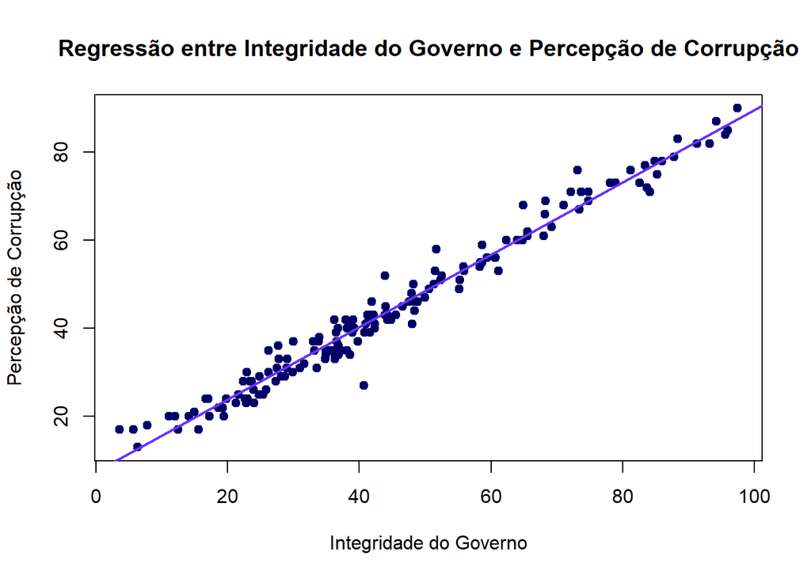

O trecho abaixo cria uma nova base agregada por regiões e pela a média de ambos os índices de cada região

```r
# Cria a base com os dados do CPI
dados_região <- dados %>%
  group_by(region) %>%
  summarise(media_CPI = mean(corruption_perception_index, na.rm = TRUE)) %>%
  arrange(desc(media_CPI))

# Adiciona os dados de liberdade econômica
dados_região <- dados_região %>%
  left_join(dados %>%
      group_by(region) %>%
      summarise(media_Overall = mean(overall_score, na.rm = TRUE)) , by = "region")

# Exibe os dados
dados_região
```

```
## # A tibble: 5 × 3
##   region                   media_CPI media_Overall
##   <chr>                        <dbl>         <dbl>
## 1 Europe                        58.0          67.4
## 2 Middle East/North Africa      43.9          57.4
## 3 Asia-Pacific                  43.3          57.4
## 4 Americas                      41.6          57.7
## 5 Sub-Saharan Africa            33.4          52.2
```

O trecho abaixo plota um gráfico de barras de cada região, comparando o CPI e a liberdade econômica de cada região agregada.

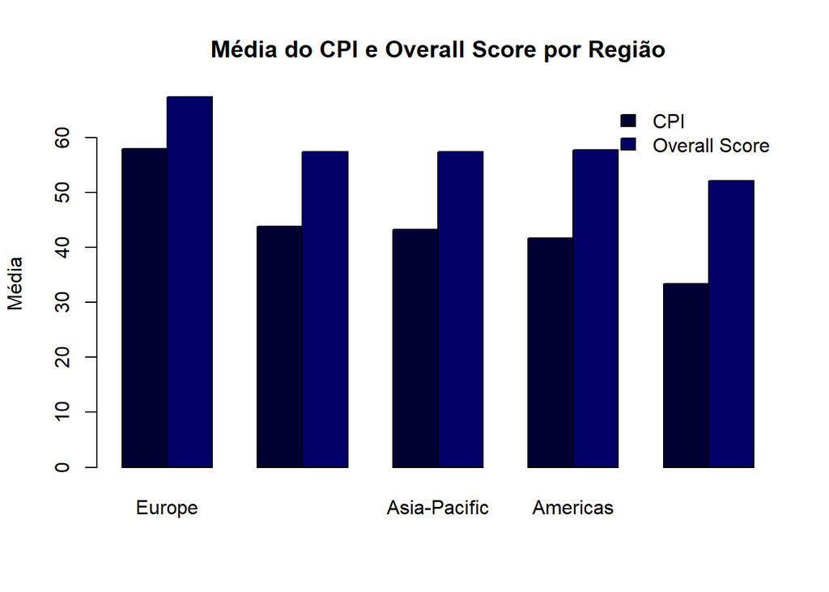

```r
# Trecho inpirado em: https://r-graph-gallery.com/barplot.html, 20 de setembro de 2024
matriz <- as.matrix(dados_região[, c("media_CPI", "media_Overall")])

barplot(height=t(matriz), names=dados_região$region ,
        col = c("#000033", "#000066"),  # Definir as cores para CPI e Overall Score
        beside = TRUE,  # Colocar as barras lado a lado
        main = "Média do CPI e Overall Score por Região",  # Título do gráfico
        ylab = "Média",  # Rótulo do eixo Y
        legend.text = c("CPI", "Overall Score"),  # Texto da legenda
        args.legend = list(x = "topright", bty = "n"))  # Posicionar a legenda
```